# Health-related quality of life in persons with apparent treatment-resistant hypertension on at least four antihypertensives | Journal of Human Hypertension

## Discussion

Treatment-resistant hypertension represents a challenging and increasingly common subset of hypertension. Although TRH has been associated with a greater risk of important adverse sequelae compared with non-resistant hypertension or no hypertension, scarce data exist on associations of TRH with humanistic outcomes like HrQoL. We compared measures of HrQoL for cohorts with aTRH versus non-resistant hypertension, using nationally representative MEPS data from 2000 through 2011. We observed a clinically significant decrement in physical HrQoL and health utility for patients with aTRH, but no similar decrement in mental HrQoL. These findings begin to address an important gap on humanistic outcomes research.<sup>13, 14</sup>

We observed a meaningful reduction in physical HrQoL among those with aTRH relative to the healthy norm (50) and relative to persons with non-resistant hypertension (mean, 43). Existing evidence has shown lower physical HrQoL in persons with any hypertension compared with those without hypertension. A recent meta-analysis of 20 studies found that hypertension was associated with a modest decrement on HrQoL across all subdomains, including PCS (−2.43; 95% CI −4.77 to −0.08) and MCS (−1.68; 95% CI −2.14 to −1.23) scores.<sup>12</sup> The difference in PCS score observed in that meta-analysis is similar to the adjusted mean difference we observed (−2.37), suggesting that aTRH may be associated with a similar incremental adverse effect on HrQoL as that seen with hypertension over no hypertension.

We did not find a significant decrement in HrQoL in the mental health domain, as measured by SF-12v2 MCS score, for aTRH versus non-resistant hypertension. Our findings seem to contrast those of a recent small uncontrolled cohort study of renal denervation by Lambert and colleagues, in which significantly lower MCS scores were observed in patients with uncontrolled TRH, as compared with age-, sex-, and BMI-matched patients with controlled non-resistant hypertension or no hypertension.<sup>26</sup> The difference in findings between that study and ours may be attributed to our use of a nationally representative panel of US adults with hypertension and aTRH being defined on the basis of using ⩾4 antihypertensives in a panel period (regardless of whether BP was controlled). In contrast, Lambert and colleagues assessed 62 patients with uncontrolled TRH who had been referred for renal denervation therapy only after BP control had been unachievable at specialized hypertension clinics. Consequently, this patient group is unlikely to be representative of the larger population of patients with aTRH in the United States. Moreover, the mean clinic BP reduction of 16/6 mm Hg 3 months after renal denervation was accompanied by an increase in mean MCS score from ~48 to 52 and no change in medication use.<sup>26</sup> Previous studies have found that systolic BP predicts variance in subjective well-being;<sup>27</sup> thus, achievement of BP control in some of these patients may account for the mean MCS score increase. In contrast, given the results of the SYMPLICITY HTN-3 trial that suggest renal denervation is no more effective than a sham procedure in this patient population,<sup>28</sup> the increase in mental functioning may reflect a placebo effect.

Finally, we observed a significant decrement in health utility, as measured by SF-6D, among persons with aTRH (0.68) relative to those with non-resistant hypertension (0.74), for a mean SF-6D difference of 0.06 in unadjusted analyses. An SF-6D utility of 0.74 for those with non-resistant hypertension is generally consistent with that observed in patients with hypertension (compared to no hypertension) in a previous large study of Medicare beneficiaries.<sup>29</sup> In addition, this difference was nearly twice that of the SF-6D score generally considered as a minimum clinically important difference (~0.03) in health status change, although this minimum difference may be less applicable when comparing groups in cross-sectional analyses such as this.<sup>30</sup> More importantly, this difference remained, though attenuated, after adjusting for covariates known to influence preference-based utilities.<sup>31, 32</sup> The adjusted difference (that is, that attributable to aTRH versus non-resistant hypertension) observed in the present study (−0.02) is similar to that attributable to hypertension generally (−0.013) and angina/CAD (−0.017).<sup>29</sup> Thus, our findings suggest that aTRH is associated with a nontrivial decrease in health utility compared with non-resistant hypertension alone. To our knowledge, this is the first report quantifying health utility associated with any measure of aTRH, so these findings will need replication. Future studies with aTRH health utilities will have special importance because of the growing emphasis on preventive and treatment strategies for TRH that are cost-effective, affordable and sustainable by health systems.

This study has noteworthy limitations. First, MEPS data do not contain BP data; thus, patients with TRH defined by uncontrolled BP on three antihypertensives (that is, according to the American Heart Association definition<sup>20</sup>) were misclassified as having non-resistant hypertension in this study. Although this group likely represents a minority of those with TRH,<sup>33</sup> we cannot exclude the possibility that this misclassification may have influenced our results. However, this misclassification would likely work against a difference between groups by reducing physical functioning and utility scores in the non-resistant hypertension group. Moreover, any influence caused by this misclassification is likely small given that we observed an approximately linear relationship between increasing number of antihypertensive medications used and both lower physical functioning and lower health utility. Indeed, in sensitivity analyses excluding any person with three antihypertensive drugs from the non-resistant hypertension group, we observed remarkably similar findings compared with the primary analysis. Second, medication adherence data are not present in MEPS. Although non-adherence is thought to be fairly common in persons with aTRH, previous studies have shown that nonadherence to antihypertensive medications may be associated with greater HrQoL that would again bias our findings towards no difference between aTRH and non-resistant hypertension. Future studies will need to better quantify the degree of nonadherence among patients with aTRH and to examine the influence of treatment adherence on the association between aTRH and reduced HrQoL and health utility. A final noteworthy point is that MEPS is a series of cross-sectional panels and not longitudinal cohorts; thus, these results should not be construed as proof of aTRH being a cause (or lack thereof) of reduced HrQoL and health utility. In part with this, HrQoL are annualized, which is a limitation inherent to MEPS.

Our findings address a gap in patient-reported and humanistic outcomes research in patients with hypertension. In particular, this report is the first, to our knowledge, to measure HrQoL and health utility for patients with aTRH in a nationally representative US population. Additional research is needed to elucidate the determinants of HrQoL in persons with aTRH, and to quantify change in HrQoL parameters and health utility associated with effective treatment of this condition.

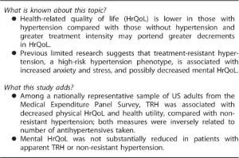

## References

1. Kearney PM, Whelton M, Reynolds K, Muntner P, Whelton PK, He J . Global burden of hypertension: analysis of worldwide data. *Lancet* 2005; **365** (9455): 217–223.

   [Article](https://doi.org/10.1016%2FS0140-6736%2805%2970151-3) Google Scholar
2. Lim SS, Vos T, Flaxman AD, Danaei G, Shibuya K, Adair-Rohani H *et al*. A comparative risk assessment of burden of disease and injury attributable to 67 risk factors and risk factor clusters in 21 regions, 1990-2010: a systematic analysis for the Global Burden of Disease Study 2010. *Lancet* 2012; **380** (9859): 2224–2260.

   [Article](https://doi.org/10.1016%2FS0140-6736%2812%2961766-8) Google Scholar
3. Egan BM, Zhao Y, Axon RN, Brzezinski WA . Ferdinand KC. Uncontrolled and apparent treatment resistant hypertension in the United States, 1988 to 2008. *Circulation* 2011; **124** (9): 1046–1058.

   [Article](https://doi.org/10.1161%2FCIRCULATIONAHA.111.030189) Google Scholar
4. Pierdomenico SD, Lapenna D, Bucci A, Di Tommaso R, Di Mascio R, Manente BM *et al*. Cardiovascular outcome in treated hypertensive patients with responder, masked, false resistant, and true resistant hypertension. *Am J Hypertens* 2005; **18** (11): 1422–1428.

   [Article](https://doi.org/10.1016%2Fj.amjhyper.2005.05.014) Google Scholar
5. Kumbhani DJ, Steg PG, Cannon CP, Eagle KA, Smith SC Jr, Crowley K *et al*. Resistant hypertension: a frequent and ominous finding among hypertensive patients with atherothrombosis. *Eur Heart J* 2013; **34** (16): 1204–1214.

   [Article](https://doi.org/10.1093%2Feurheartj%2Fehs368) [CAS](https://www.nature.com/articles/cas-redirect/1:CAS:528:DC%2BC3sXmtlCjsb4%3D) Google Scholar
6. De Nicola L, Gabbai FB, Agarwal R, Chiodini P, Borrelli S, Bellizzi V *et al*. Prevalence and prognostic role of resistant hypertension in chronic kidney disease patients. *J Am Coll Cardiol* 2013; **61** (24): 2461–2467.

   [Article](https://doi.org/10.1016%2Fj.jacc.2012.12.061) Google Scholar
7. Smith SM, Gong Y, Handberg E, Messerli FH, Bakris GL, Ahmed A *et al*. Predictors and outcomes of resistant hypertension among patients with coronary artery disease and hypertension. *J Hypertens* 2014; **32** (3): 635–643.

   [Article](https://doi.org/10.1097%2FHJH.0000000000000051) [CAS](https://www.nature.com/articles/cas-redirect/1:CAS:528:DC%2BC2cXhsVCgtLo%3D) Google Scholar
8. Smith SM, Huo T, Delia Johnson B, Bittner V, Kelsey SF, Vido Thompson D *et al*. Cardiovascular and mortality risk of apparent resistant hypertension in women with suspected myocardial ischemia: a report from the NHLBI-sponsored WISE Study. *J Am Heart Assoc* 2014; **3** (1): e000660.

   [Article](https://doi.org/10.1161%2FJAHA.113.000660) Google Scholar
9. Daugherty SL, Powers JD, Magid DJ, Tavel HM, Masoudi FA, Margolis KL *et al*. Incidence and prognosis of resistant hypertension in hypertensive patients. *Circulation* 2012; **125** (13): 1635–1642.

   [Article](https://doi.org/10.1161%2FCIRCULATIONAHA.111.068064) Google Scholar
10. Bangalore S, Fayyad R, Laskey R, Demicco DA, Deedwania P, Kostis JB *et al*. Prevalence, predictors, and outcomes in treatment-resistant hypertension in patients with coronary disease. *Am J Med* 2014; **127** (1): 71–81.

    [Article](https://doi.org/10.1016%2Fj.amjmed.2013.07.038) Google Scholar
11. Irvin MR, Booth JN 3rd, Shimbo D, Lackland DT, Oparil S, Howard G *et al*. Apparent treatment-resistant hypertension and risk for stroke, coronary heart disease and all-cause mortality. *J Am Soc Hypertens* 2014; **8** (6): 405–413.

    [Article](https://doi.org/10.1016%2Fj.jash.2014.03.003) Google Scholar
12. Trevisol DJ, Moreira LB, Kerkhoff A, Fuchs SC, Fuchs FD . Health-related quality of life and hypertension: a systematic review and meta-analysis of observational studies. *J Hypertens* 2011; **29**: 179–188.

    [Article](https://doi.org/10.1097%2FHJH.0b013e328340d76f) [CAS](https://www.nature.com/articles/cas-redirect/1:CAS:528:DC%2BC3cXhs1aks73P) Google Scholar
13. Vemulapalli S, Ard J, Bakris GL, Bhatt DL, Brown AS, Cushman WC *et al*. Proceedings from duke resistant hypertension think tank. *Am Heart J* 2014; **167** (6): 775–788.

    [Article](https://doi.org/10.1016%2Fj.ahj.2014.02.008) Google Scholar
14. Rumsfeld JS, Alexander KP, Goff DC Jr, Graham MM, Ho PM, Masoudi FA *et al*. Cardiovascular health: the importance of measuring patient-reported health status: a scientific statement from the American Heart Association. *Circulation* 2013; **127** (22): 2233–2249.

    [Article](https://doi.org/10.1161%2FCIR.0b013e3182949a2e) Google Scholar
15. Ware JE, Kosinski M, Keller SD . A 12-item short-form health survey: Construction of scales and preliminary tests of reliability and validity. *Med Care* 1996; **34**: 220–233.

    [Article](https://doi.org/10.1097%2F00005650-199603000-00003) Google Scholar
16. Brazier JE, Roberts J . The estimation of a preference-based measure of health from the SF-12. *Med Care* 2004; **42**: 851–859.

    [Article](https://doi.org/10.1097%2F01.mlr.0000135827.18610.0d) Google Scholar
17. Norman GR, Sloan JA, Wyrwich KW . Interpretation of changes in health-related quality of life: the remarkable universality of half a standard deviation. *Med Care* 2003; **41** (5): 582–592.

    [PubMed](http://www.ncbi.nlm.nih.gov/entrez/query.fcgi?cmd=Retrieve&db=PubMed&dopt=Abstract&list_uids=12719681) Google Scholar
18. Poljicanin T, Ajdukovic D, Sekerija M, Pibernik-Okanovic M, Metelko Z, Vuletic Mavrinac G . Diabetes mellitus and hypertension have comparable adverse effects on health-related quality of life. *BMC Public Health* 2010; **10**: 12.

    [Article](https://doi.org/10.1186%2F1471-2458-10-12) Google Scholar
19. Stewart AL, Greenfield S, Hays RD, Wells K, Rogers WH, Berry SD *et al*. Functional status and well-being of patients with chronic conditions. Results from the Medical Outcomes Study. *JAMA* 1989; **262** (7): 907–913.

    [Article](https://doi.org/10.1001%2Fjama.1989.03430070055030) [CAS](https://www.nature.com/articles/cas-redirect/1:STN:280:DyaL1MzivFWhtQ%3D%3D) Google Scholar
20. Calhoun DA, Jones D, Textor S, Goff DC, Murphy TP, Toto RD *et al*. Resistant hypertension: diagnosis, evaluation, and treatment: a scientific statement from the American Heart Association Professional Education Committee of the Council for High Blood Pressure Research. *Circulation* 2008; **117** (25): e510–e526.

    [Article](https://doi.org/10.1161%2FCIRCULATIONAHA.108.189141) Google Scholar
21. Trevisol DJ, Moreira LB, Fuchs FD, Fuchs SC . Health-related quality of life is worse in individuals with hypertension under drug treatment: results of population-based study. *J Hum Hypertens* 2012; **26**: 374–380.

    [Article](https://doi.org/10.1038%2Fjhh.2011.48) [CAS](https://www.nature.com/articles/cas-redirect/1:CAS:528:DC%2BC38XntVSnt70%3D) Google Scholar
22. Korhonen PE, Kivelä SL, Kautiainen H, Jarvenpaa S, Kantola I . Health-related quality of life and awareness of hypertension. *J Hypertens* 2011; **29**: 2070–2074.

    [Article](https://doi.org/10.1097%2FHJH.0b013e32834bbca7) [CAS](https://www.nature.com/articles/cas-redirect/1:CAS:528:DC%2BC3MXht12rsLjL) Google Scholar
23. Li W, Liu L, Puente JG, Li Y, Jiang X, Jin S *et al*. Hypertension and health-related quality of life: An epidemiological study in patients attending hospital clinics in China. *J Hypertens* 2005; **23**: 1667–1676.

    [Article](https://doi.org/10.1097%2F01.hjh.0000174971.64589.39) [CAS](https://www.nature.com/articles/cas-redirect/1:CAS:528:DC%2BD2MXnt1ykurs%3D) Google Scholar
24. Mena-Martin FJ, Martin-Escudero JC, Simal-Blanco F, Carretero-Ares JL, Arzua-Mouronte D, Herreros-Fernandez V . Health-related quality of life of subjects with known and unknown hypertension: results from the population-based Hortega study. *J Hypertens* 2003; **21**: 1283–1289.

    [Article](https://doi.org/10.1097%2F00004872-200307000-00015) [CAS](https://www.nature.com/articles/cas-redirect/1:CAS:528:DC%2BD3sXmsVaitLY%3D) Google Scholar
25. Banegas JR, Guallar-Castillon P, Rodriguez-Artalejo F, Graciani A, Lopez-Garcia E, Ruilope LM . Association between awareness, treatment, and control of hypertension and quality of life among older adults in Spain. *Am J Hypertens* 2006; **19**: 686–693.

    [Article](https://doi.org/10.1016%2Fj.amjhyper.2006.01.015) Google Scholar
26. Lambert GW, Hering D, Esler MD, Marusic P, Lambert EA, Tanamas SK *et al*. Health-related quality of life after renal denervation in patients with treatment-resistant hypertension. *Hypertension* 2012; **60** (6): 1479–1484.

    [Article](https://doi.org/10.1161%2FHYPERTENSIONAHA.112.200865) [CAS](https://www.nature.com/articles/cas-redirect/1:CAS:528:DC%2BC38Xhs1GqsrbO) Google Scholar
27. Gong Y, Handberg EM, Gerhard T, Cooper-DeHoff RM, Ried LD, Johnson JA *et al*. Systolic blood pressure and subjective well-being in patients with coronary artery disease. *Clin Cardiol* 2009; **32** (11): 627–632.

    [Article](https://doi.org/10.1002%2Fclc.20501) Google Scholar
28. Bhatt DL, Kandzari DE, O'Neill WW, D’Agostino R, Flack JM, Katzen BT *et al*. A controlled trial of renal denervation for resistant hypertension. *N Engl J Med* 2014; **370**: 1393–1401.

    [Article](https://doi.org/10.1056%2FNEJMoa1402670) [CAS](https://www.nature.com/articles/cas-redirect/1:CAS:528:DC%2BC2cXmsVWrurg%3D) Google Scholar
29. Hays RD, Reeve BB, Smith AW, Clauser SB . Associations of cancer and other chronic medical conditions with SF-6D preference-based scores in Medicare beneficiaries. *Qual Life Res* 2014; **23**: 385–391.

    [Article](https://doi.org/10.1007%2Fs11136-013-0503-9) Google Scholar
30. Walters SJ, Brazier JE . What is the relationship between the minimally important difference and health state utility values? The case of the SF-6D. *Health Qual Life Outcomes* 2003; **1**: 4.

    [Article](https://doi.org/10.1186%2F1477-7525-1-4) Google Scholar
31. Hanmer J, Lawrence WF, Anderson JP, Kaplan RM, Fryback DG . Report of nationally representative values for the noninstitutionalized US adult population for 7 health-related quality-of-life scores. *Med Decis Making* 2006; **26** (4): 391–400.

    [Article](https://doi.org/10.1177%2F0272989X06290497) Google Scholar
32. Sullivan PW, Ghushchyan V . Preference-based EQ-5D index scores for chronic conditions in the United States. *Med Dec Making* 2006; **26**: 410–420.

    [Article](https://doi.org/10.1177%2F0272989X06290495) Google Scholar
33. Smith SM . Epidemiology, prognosis, and treatment of resistant hypertension. *Pharmacotherapy* 2013; **33** (10): 1071–1086.

    [Article](https://doi.org/10.1002%2Fphar.1297) Google Scholar

[Download references](https://citation-needed.springer.com/v2/references/10.1038/jhh.2015.61?format=refman&flavour=references)

## Author information

### Authors and Affiliations

1. Departments of Pharmacotherapy & Translational Research and Community Health & Family Medicine, Colleges of Pharmacy and Medicine, University of Florida, Gainesville, FL, USA

   N W Carris & S M Smith
2. Department of Economics, American University of Armenia, Yerevan, Armenia

   V Ghushchyan
3. Department of Clinical Pharmacy and Center for Pharmaceutical Outcomes Research, Skaggs School of Pharmacy and Pharmaceutical Sciences, University of Colorado, Aurora, CO, USA

   V Ghushchyan & A M Libby

### Corresponding author

Correspondence to S M Smith.

## Ethics declarations

### Competing interests

The authors declare no conflict of interest.

## Rights and permissions

Reprints and Permissions

## About this article

### Cite this article

Carris, N., Ghushchyan, V., Libby, A. *et al.* Health-related quality of life in persons with apparent treatment-resistant hypertension on at least four antihypertensives. *J Hum Hypertens* **30**, 191–196 (2016). https://doi.org/10.1038/jhh.2015.61

[Download citation](https://citation-needed.springer.com/v2/references/10.1038/jhh.2015.61?format=refman&flavour=citation)

- Received: 20 March 2015
- Revised: 27 April 2015
- Accepted: 14 May 2015
- Published: 18 June 2015
- Issue Date: March 2016
- DOI: https://doi.org/10.1038/jhh.2015.61

### Subjects

- [Hypertension](https://www.nature.com/subjects/hypertension)

## This article is cited by

### [Resistant Hypertension: Mechanisms and Treatment](https://doi.org/10.1007/s11906-017-0754-x)

- - Andrew Y. Hwang
  - Eric Dietrich
  - Steven M. Smith

  *Current Hypertension Reports* (2017)

### [Quality of Life in Treatment-Resistant Hypertension](https://doi.org/10.1007/s11906-015-0578-5)

- - Nicholas W. Carris
  - Steven M. Smith

  *Current Hypertension Reports* (2015)